# Check the Potr genomes gene overlap, pairwise, with a 1bp overlap

Nicolas Delhomme

2015-06-16

# 1 Setup

Set the working dir

```r
setwd("/mnt/picea/projects/aspseq/asp201/rna/BEDTools/")
```

Load libraries

```r
suppressPackageStartupMessages(library(Biostrings))
suppressPackageStartupMessages(library(igraph))
suppressPackageStartupMessages(library(matrixStats))
suppressPackageStartupMessages(library(pander))
suppressPackageStartupMessages(library(parallel))
```

And helpers

```r
source("~/Git/UPSCb/src/R/plot.multidensity.R")
```

# 2 Perform the assessment

Reading in all the pairwise intersect data

```r
res <- mclapply(dir(".",pattern=".*-1bp\\.tsv"),read.delim,
                stringsAsFactors=FALSE,header=FALSE,mc.cores=6L)

names(res) <- sub("-1bp\\.tsv","",dir(".",pattern=".*-1bp\\.tsv"))
```

Create a list of edges

```r
edges.list <- lapply(res,"[",c(9,18))
edges.list <- lapply(edges.list,function(edges){
  cbind(sub(";.*","",sub(".*Name=","",edges[,1])),
        gsub(".*Name=|\\.0$","",edges[,2]))})
```

Report on the number of links and the number of missing

```r
stats <- do.call(rbind,lapply(edges.list,function(edges){
  tab <- table(table(edges[,2]))
  mult <- rep(as.integer(names(tab[-c(1,length(tab))])),tab[-c(1,length(tab))])
  c(total=nrow(edges),
    gene=length(unique(edges[,1])),
    gene.mapped=length(unique(edges[,2]))-1,
    gene.unique.mapped=sum(table(edges[,2])==1),
    gene.multi=sum(table(edges[,2])>1) - 1,
    gene.multi.mean=mean(mult),
    gene.multi.median=median(mult),
    gene.multi.sd=sd(mult),
    gene.multi.min=min(mult),
    gene.multi.max=max(mult),
    gene.missed=sum(edges[,2]==".")
    )
}))
```

Print it

```r
pander(stats)
```

Table continues below

|  | total | gene | gene.mapped |
| --- | --- | --- | --- |
| **Potra01-Potri03** | 57432 | 36144 | 38978 |
| **Potra01-Potrs01** | 54703 | 36144 | 37396 |
| **Potri03-Potra01** | 56785 | 41335 | 34855 |
| **Potri03-Potrs01** | 55221 | 41335 | 35912 |
| **Potrs01-Potra01** | 54106 | 37778 | 35670 |
| **Potrs01-Potri03** | 54415 | 37778 | 37877 |

Table continues below

|  | gene.unique.mapped | gene.multi |
| --- | --- | --- |
| **Potra01-Potri03** | 30146 | 8832 |
| **Potra01-Potrs01** | 28852 | 8544 |
| **Potri03-Potra01** | 25595 | 9260 |
| **Potri03-Potrs01** | 28256 | 7656 |
| **Potrs01-Potra01** | 25822 | 9848 |
| **Potrs01-Potri03** | 29824 | 8053 |

Table continues below

|  | gene.multi.mean | gene.multi.median |
| --- | --- | --- |
| **Potra01-Potri03** | 2.767 | 2 |
| **Potra01-Potrs01** | 2.826 | 2 |
| **Potri03-Potra01** | 2.817 | 2 |
| **Potri03-Potrs01** | 2.693 | 2 |
| **Potrs01-Potra01** | 2.658 | 2 |
| **Potrs01-Potri03** | 2.477 | 2 |

Table continues below

|  | gene.multi.sd | gene.multi.min |
| --- | --- | --- |
| **Potra01-Potri03** | 3.772 | 2 |
| **Potra01-Potrs01** | 1.906 | 2 |
| **Potri03-Potra01** | 2.168 | 2 |
| **Potri03-Potrs01** | 1.897 | 2 |
| **Potrs01-Potra01** | 1.059 | 2 |
| **Potrs01-Potri03** | 0.9142 | 2 |

|  | gene.multi.max | gene.missed |
| --- | --- | --- |
| **Potra01-Potri03** | 98 | 2847 |
| **Potra01-Potrs01** | 94 | 1702 |
| **Potri03-Potra01** | 47 | 5106 |
| **Potri03-Potrs01** | 36 | 6349 |
| **Potrs01-Potra01** | 15 | 2106 |
| **Potrs01-Potri03** | 10 | 4647 |

Graph the edges list

```r
edges.graf <- lapply(lapply(edges.list,function(edges){edges[edges[,2]!=".",]}),
                      graph.edgelist,directed=FALSE)
```

Get their stats

```r
graf.stats <- do.call(rbind,lapply(edges.graf,function(graf){
  cl <- clusters(graf)
  c(clusters=cl$no,
    singleton=sum(cl$csize==2),
    multiple=length(cl$csize[cl$csize>2]),
    mean=mean(cl$csize[cl$csize>2]-1),
    median=median(cl$csize[cl$csize>2]-1),
    sd=sd(cl$csize[cl$csize>2]-1),
    min=min(cl$csize[cl$csize>2]-1),
    max=max(cl$csize[cl$csize>2]-1))
}))
```

And print them

```r
pander(graf.stats)
```

Table continues below

|  | clusters | singleton | multiple | mean |
| --- | --- | --- | --- | --- |
| **Potra01-Potri03** | 25527 | 18252 | 7275 | 3.938 |
| **Potra01-Potrs01** | 26941 | 20595 | 6346 | 3.839 |
| **Potri03-Potra01** | 26022 | 19928 | 6094 | 4.124 |
| **Potri03-Potrs01** | 26789 | 20654 | 6135 | 3.823 |
| **Potrs01-Potra01** | 26804 | 20321 | 6483 | 3.744 |
| **Potrs01-Potri03** | 25962 | 18587 | 7375 | 3.606 |

|  | median | sd | min | max |
| --- | --- | --- | --- | --- |
| **Potra01-Potri03** | 3 | 6.574 | 2 | 264 |
| **Potra01-Potrs01** | 3 | 5.488 | 2 | 178 |
| **Potri03-Potra01** | 3 | 8.97 | 2 | 349 |
| **Potri03-Potrs01** | 3 | 8.766 | 2 | 467 |
| **Potrs01-Potra01** | 3 | 4.686 | 2 | 134 |
| **Potrs01-Potri03** | 3 | 5.127 | 2 | 198 |

Combined graph

```r
graf <- graph.edgelist(do.call(rbind,
                               lapply(edges.list,
                                      function(edges){edges[edges[,2]!=".",]})))
```

Look at the clusters

```r
cl <- clusters(graf)
sprintf("There are %s clusters",cl$no)
```

```
## [1] "There are 20569 clusters"
```

and the table of the cluster sizes

```r
pander(sort(table(cl$csize),decreasing=TRUE),
       caption="Occurence (upper row) of the different cluster sizes (lower row)")
```

Table continues below

| 3 | 4 | 6 | 7 | 5 | 8 | 9 | 2 | 10 | 11 |
| --- | --- | --- | --- | --- | --- | --- | --- | --- | --- |
| 12507 | 2371 | 1478 | 829 | 777 | 516 | 331 | 315 | 251 | 177 |

Table continues below

| 12 | 14 | 13 | 15 | 16 | 17 | 18 | 20 | 19 | 22 |
| --- | --- | --- | --- | --- | --- | --- | --- | --- | --- |
| 160 | 126 | 112 | 81 | 67 | 53 | 47 | 37 | 34 | 26 |

Table continues below

| 21 | 23 | 25 | 24 | 26 | 27 | 28 | 29 | 32 | 31 |
| --- | --- | --- | --- | --- | --- | --- | --- | --- | --- |
| 21 | 16 | 15 | 13 | 13 | 12 | 11 | 11 | 9 | 7 |

Table continues below

| 33 | 39 | 35 | 37 | 42 | 40 | 48 | 50 | 56 | 38 |
| --- | --- | --- | --- | --- | --- | --- | --- | --- | --- |
| 7 | 7 | 6 | 6 | 6 | 5 | 5 | 5 | 5 | 4 |

Table continues below

| 45 | 54 | 30 | 34 | 36 | 46 | 51 | 62 | 41 | 43 |
| --- | --- | --- | --- | --- | --- | --- | --- | --- | --- |
| 4 | 4 | 3 | 3 | 3 | 3 | 3 | 3 | 2 | 2 |

Table continues below

| 44 | 55 | 58 | 59 | 64 | 66 | 70 | 71 | 78 | 83 |
| --- | --- | --- | --- | --- | --- | --- | --- | --- | --- |
| 2 | 2 | 2 | 2 | 2 | 2 | 2 | 2 | 2 | 2 |

Table continues below

| 86 | 87 | 95 | 131 | 49 | 53 | 60 | 63 | 65 |
| --- | --- | --- | --- | --- | --- | --- | --- | --- |
| 2 | 2 | 2 | 2 | 1 | 1 | 1 | 1 | 1 |

Table continues below

| 68 | 69 | 77 | 79 | 81 | 84 | 85 | 88 | 91 | 93 |
| --- | --- | --- | --- | --- | --- | --- | --- | --- | --- |
| 1 | 1 | 1 | 1 | 1 | 1 | 1 | 1 | 1 | 1 |

Table continues below

| 94 | 103 | 105 | 116 | 121 | 137 | 138 | 142 | 144 |
| --- | --- | --- | --- | --- | --- | --- | --- | --- |
| 1 | 1 | 1 | 1 | 1 | 1 | 1 | 1 | 1 |

| 147 | 152 | 153 | 158 | 161 | 172 | 218 | 12802 |
| --- | --- | --- | --- | --- | --- | --- | --- |
| 1 | 1 | 1 | 1 | 1 | 1 | 1 | 1 |

Draw some examples

DEFINITELY NOT the one with the max vertices - 12802!!! - seriously??

```r
baron <- induced.subgraph(graf,get.vertex.attribute(graf,"name")[which(clusters(graf)$membership == which.max(clusters(graf)$csize))])
```

An example with 3 (the most frequent)

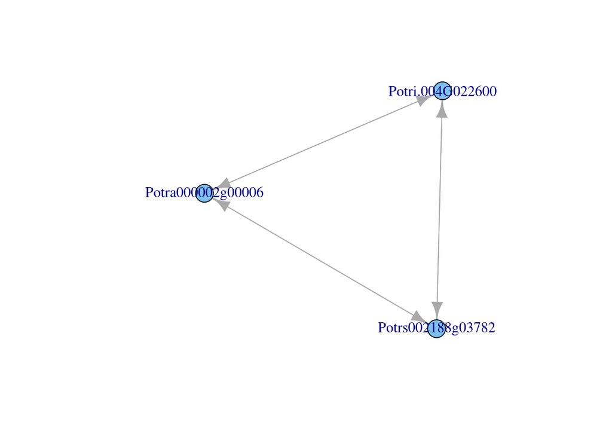

```r
baron <- induced.subgraph(graf,get.vertex.attribute(graf,"name")[which(clusters(graf)$membership == which(clusters(graf)$csize==3)[1])])
plot.igraph(baron)
```

An example with 2

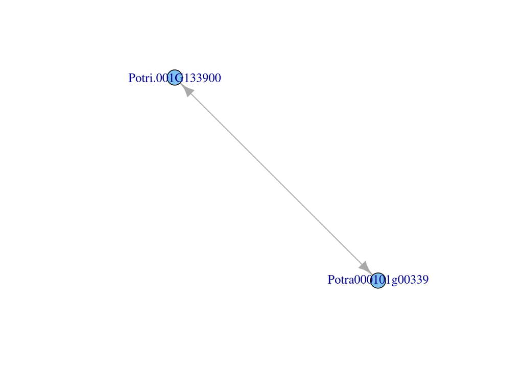

```r
baron <- induced.subgraph(graf,get.vertex.attribute(graf,"name")[which(clusters(graf)$membership == which(clusters(graf)$csize==2)[1])])
plot.igraph(baron)
```

An example with 4

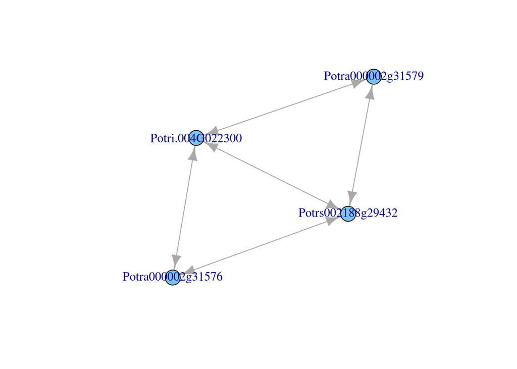

```r
baron <- induced.subgraph(graf,get.vertex.attribute(graf,"name")[which(clusters(graf)$membership == which(clusters(graf)$csize==4)[1])])
plot.igraph(baron)
```

An example with 5

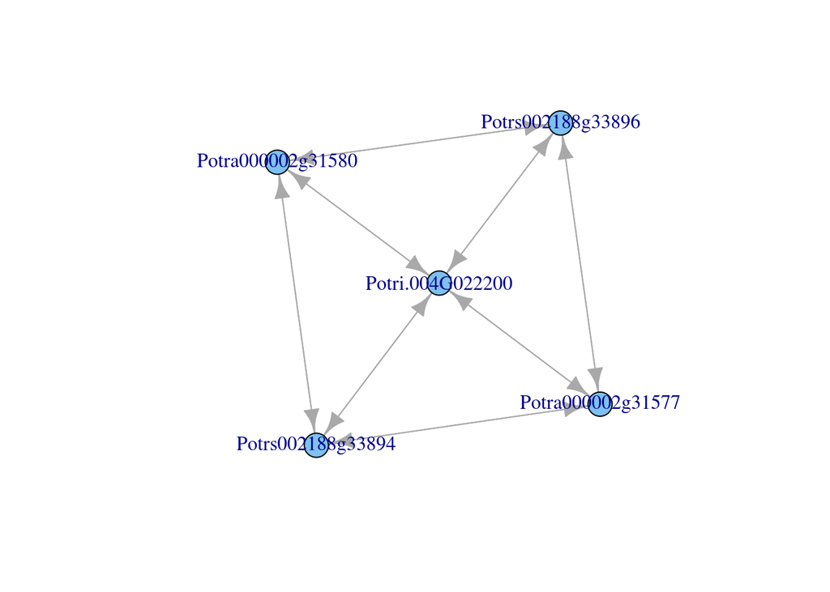

```r
baron <- induced.subgraph(graf,get.vertex.attribute(graf,"name")[which(clusters(graf)$membership == which(clusters(graf)$csize==5)[1])])
plot.igraph(baron)
```

An example with 6

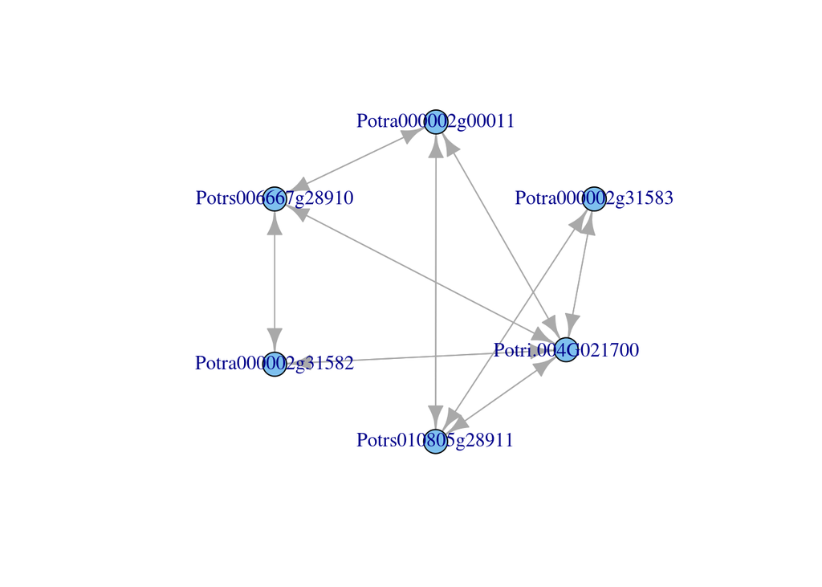

```r
baron <- induced.subgraph(graf,get.vertex.attribute(graf,"name")[which(clusters(graf)$membership == which(clusters(graf)$csize==6)[1])])
plot.igraph(baron,layout=layout.spring(baron))
```

This all looks good, let’s count the number of clusters and how many species are involved in each

```r
cluster.members.mat <- do.call(rbind,lapply(lapply(lapply(split(get.vertex.attribute(graph = graf,name="name"),
                                         clusters(graf)$membership),substr,1,5),
                            factor,levels=c("Potra","Potri","Potrs")),table))
```

Cluster numbers:

```r
nrow(cluster.members.mat)
```

```
## [1] 20569
```

Number of genes per species

```r
pander(colSums(cluster.members.mat))
```

| Potra | Potri | Potrs |
| --- | --- | --- |
| 36140 | 39770 | 37832 |

Number of “absent” gene per species

```r
pander(colSums(cluster.members.mat==0))
```

| Potra | Potri | Potrs |
| --- | --- | --- |
| 42 | 373 | 110 |

```r
pander(table(rowSums(cluster.members.mat==0)))
```

| 0 | 1 | 2 |
| --- | --- | --- |
| 20046 | 521 | 2 |

All of them imply 1 gene, which are due to some gene names not being Potr[a,i,s]

```r
pander(cluster.members.mat[(rowSums(cluster.members.mat==0))==2,])
```

|  | Potra | Potri | Potrs |
| --- | --- | --- | --- |
| **20279** | 0 | 0 | 1 |
| **20561** | 1 | 0 | 0 |

Number of unique genes per cluster

```r
pander(table(rowSums(cluster.members.mat==1)))
```

| 0 | 1 | 2 | 3 |
| --- | --- | --- | --- |
| 4313 | 892 | 3006 | 12358 |

Number of identical number of genes per cluster

```r
sum(rowSds(cluster.members.mat)==0)
```

```
## [1] 13881
```

And their occurences

```r
table(cluster.members.mat[rowSds(cluster.members.mat)==0,1])
```

```
##
##     1     2     3     4     5     6     7    11    14
## 12358  1283   157    51    19     7     4     1     1
```

Number of unique genes per species

```r
pander(colSums(cluster.members.mat==1))
```

| Potra | Potri | Potrs |
| --- | --- | --- |
| 15378 | 13776 | 14824 |

Number of multiple genes per species It would seem like Potra is more collapsed

```r
pander(colSums(cluster.members.mat>1))
```

| Potra | Potri | Potrs |
| --- | --- | --- |
| 5149 | 6420 | 5635 |

Stats of the multiple genes

mean

```r
pander(sapply(1:3,function(i,mat){mean(mat[mat[,i]>1,i])},cluster.members.mat))
```

*4.032*, *4.049* and *4.083*

median

```r
pander(sapply(1:3,function(i,mat){median(mat[mat[,i]>1,i])},cluster.members.mat))
```

*2*, *2* and *2*

max

```r
pander(sapply(1:3,function(i,mat){max(mat[mat[,i]>1,i])},cluster.members.mat))
```

*3786*, *4937* and *4040*

min

```r
pander(sapply(1:3,function(i,mat){min(mat[mat[,i]>1,i])},cluster.members.mat))
```

*2*, *2* and *2*

Number of clusters presents in Potr[as] but not Potri

```r
Potras.clusters <- which(rowSums(cluster.members.mat[,c("Potra","Potrs")] >= 1)==2  & cluster.members.mat[,"Potri"] == 0)
length(Potras.clusters)
```

```
## [1] 371
```

Number of corresponding genes

```r
sum(clusters(graf)$csize[Potras.clusters])
```

```
## [1] 1127
```

Distribution of the cluster size

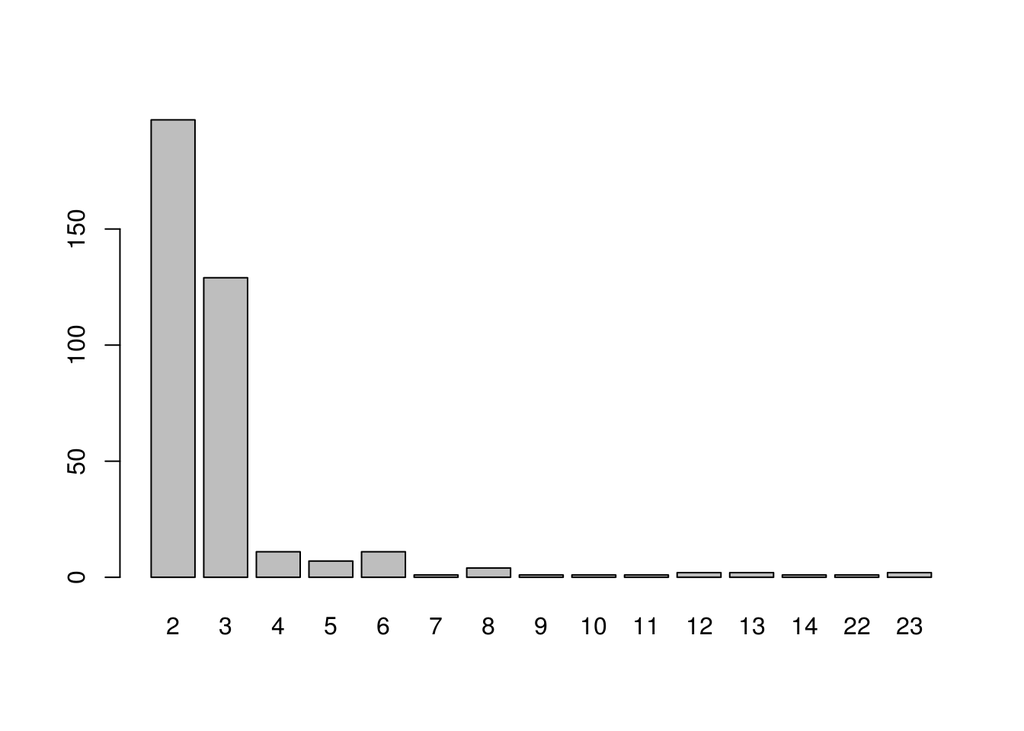

```r
barplot(table(clusters(graf)$csize[Potras.clusters]))
```

Check if one species has more gene than the other (pre cluster Potra - Potrs) We seen to have more copies in Potrs, so Potra appears more collapsed.

```r
pander(table(cluster.members.mat[Potras.clusters,1] - cluster.members.mat[Potras.clusters,3]))
```

| -3 | -1 | 0 | 1 | 2 | 6 |
| --- | --- | --- | --- | --- | --- |
| 2 | 60 | 286 | 17 | 5 | 1 |

Get the gene IDs

```r
IDs <- get.vertex.attribute(graf,"name")[which(clusters(graf)$membership %in% Potras.clusters)]
```

If we drop the pre-miRNA

```r
pander(table(substr(IDs[grep("Potra",IDs)],1,5)))
```

| Potra |
| --- |
| 480 |

Load the protein sequences

```r
Potra01p <- readAAStringSet("/mnt/picea/storage/reference/Populus-tremula/v1.0/fasta/Potra01-protein-in-frame-representative.fa.gz")
Potrs01p <- readAAStringSet("/mnt/picea/storage/reference/Populus-tremuloides/v1.0/fasta/Potrs01-protein-in-frame-representative.fa.gz")
```

Out of these, about half are coding

```r
pander(table(IDs[grep("Potra",IDs)] %in% sub("\\.[0-9]+ .*","",names(Potra01p))))
```

| FALSE | TRUE |
| --- | --- |
| 228 | 252 |

```r
pander(table(IDs[grep("Potrs",IDs)] %in% sub("\\.[0-9]+ .*","",names(Potrs01p))))
```

| FALSE | TRUE |
| --- | --- |
| 265 | 248 |

Plot their sizes - obviously on the lower scale

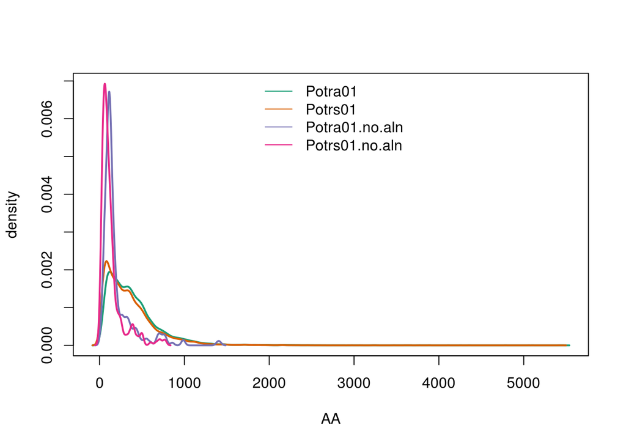

```r
plot.multidensity(list(Potra01=width(Potra01p),
                       Potrs01=width(Potrs01p),
                       Potra01.no.aln=width(Potra01p[sub("\\.[0-9]+ .*","",names(Potra01p)) %in% IDs[grep("Potra",IDs)]]),
                       Potrs01.no.aln=width(Potrs01p[sub("\\.[0-9]+ .*","",names(Potrs01p)) %in% IDs[grep("Potrs",IDs)]])
),lwd=2,xlab="AA")
```

and export their IDs

```r
write(IDs[grep("Potra",IDs)][IDs[grep("Potra",IDs)] %in% sub("\\.[0-9]+ .*","",names(Potra01p))],"Potra01-Potr-specific-IDs.txt")
write(IDs[grep("Potrs",IDs)][IDs[grep("Potrs",IDs)] %in% sub("\\.[0-9]+ .*","",names(Potrs01p))],"Potrs01-Potr-specific-IDs.txt")
```